# Practical 7

Kevin Patyk

1/19/2022

# Introduction

In this practical, we are going to use the following packages to create document-term matrices on BBC news data set and apply LDA topic modeling.

```r
library(tidyverse)
library(tidytext)
library(tm)
library(e1071)
library(topicmodels)
library(stringi)
```

# Vector space model: document-term matrix

The data set used in this practical is the BBC News data set. You can use the provided `news_dataset.rda` for this purpose.

This data set consists of 2225 documents from the BBC news website corresponding to stories in five topical areas from 2004 to 2005. These areas are:

- Business
- Entertainment
- Politics
- Sport
- Tech

**1: Use the code below to load the data set and inspect its first rows.**

```r
load("news_dataset.rda")
head(df_final)
```

```
##   File_Name
## 1   001.txt
## 2   002.txt
## 3   003.txt
## 4   004.txt
## 5   005.txt
## 6   006.txt
##                                                                                                                                                                                                                                                                                                          …
## 1 Ad sales boost Time Warner profit\n\nQuarterly profits at US media giant TimeWarner jumped 76% to $1.13bn (Â£600m) for the three months to December, from $639m year-earlier.\n\nThe firm, which is now one of the biggest investors in Google, benefited from sales of high-speed internet connections…
## 2                                                                                                                                                                                                                                                                                                        …
## 3                                                                                                                                                                                                                                                                                                        …
## 4                                                                                                                                                     High fuel prices hit BA's profits\n\nBritish Airways has blamed high fuel prices for a 40% drop in profits.\n\nReporting its results for the three …
## 5                                                                                                                                                                                                                                                                                                        …
## 6                                                                                                                                                                                                                                                                                                        …
##   Category Complete_Filename
## 1 business  001.txt-business
## 2 business  002.txt-business
## 3 business  003.txt-business
## 4 business  004.txt-business
## 5 business  005.txt-business
## 6 business  006.txt-business
```

**2: Find out about the name of the categories and the number of observations in each of them.**

```r
table(df_final$Category)
```

```
##
##      business entertainment      politics         sport          tech
##           510           386           417           511           401
```

There are 5 categories: business, entertainment, politics, sport, and tech. The number of observations per category, in order, are: 510, 386, 417, 511, and 401.

**3: Convert the data set into a document-term matrix and use the findFreqTerms function to keep the terms which their frequency is higher than 10. It is also a good idea to apply some text preprocessing before this conversion: e.g., remove non-UTF-8 characters, convert the words into lowercase, remove punctuation, numbers, stopwords, and whitespaces.**

```r
## set the seed to make your partition reproducible
set.seed(123)

docs <- Corpus(VectorSource(df_final$Content))

# we can create the dtm matrix in on-go or with separate functions as below
# dtm <- DocumentTermMatrix(docs,
#            control = list(tolower = TRUE,
#                           removeNumbers = TRUE,
#                           removePunctuation = TRUE,
#                           stopwords = TRUE
#                          ))

# remove non-UTF-8 characters
docs <- tm_map(docs, iconv, from = "UTF-8", to = "UTF-8", sub = '')
# standardize to lowercase
docs <- tm_map(docs, content_transformer(tolower))
# remove tm stopwords
docs <- tm_map(docs, removeWords, stopwords())
# standardize whitespaces
docs <- tm_map(docs, stripWhitespace)
# remove punctuation
docs <- tm_map(docs, removePunctuation)
# remove numbers
docs <- tm_map(docs, removeNumbers)

dtm <- DocumentTermMatrix(docs)

# words appearing more than 10x
features <- findFreqTerms(dtm, 10)
head(features)
```

```
## [1] "accounts"    "advert"      "advertising" "alexander"   "already"
## [6] "also"
```

**4: Partition the original data into training and test sets with 80% for training and 20% for test.**

```r
## 80% of the sample size
smp_size <- floor(0.80 * nrow(df_final))

set.seed(123)
train_idx <- sample(seq_len(nrow(df_final)), size = smp_size)

# set for the original raw data
train1 <- df_final[train_idx,]
test1  <- df_final[-train_idx,]

# set for the cleaned-up data
train2 <- docs[train_idx]
test2  <- docs[-train_idx]
```

**5: Create separate document-term matrices for the training and the test sets using the previous frequent terms as the input dictionary and convert them into data frames.**

```r
dtm_train <- DocumentTermMatrix(train2, list(dictionary = features))
dtm_test  <- DocumentTermMatrix(test2, list(dictionary = features))

dtm_train <- as.data.frame(as.matrix(dtm_train))
dtm_test  <- as.data.frame(as.matrix(dtm_test))
```

```r
dtm_train <- cbind(cat = factor(train1$Category), dtm_train)
dtm_test  <- cbind(cat = factor(test1$Category), dtm_test)
dtm_train <- as.data.frame(dtm_train)
dtm_test  <- as.data.frame(dtm_test)
```

```r
fit_svm <- svm(cat ~ ., data = dtm_train)
summary(fit_svm)
```

```
##
## Call:
## svm(formula = cat ~ ., data = dtm_train)
##
##
## Parameters:
##    SVM-Type:  C-classification
##  SVM-Kernel:  radial
##        cost:  1
##
## Number of Support Vectors:  1488
##
##  ( 292 358 247 259 332 )
##
##
## Number of Classes:  5
##
## Levels:
##  business entertainment politics sport tech
```

```r
# prediction on training data
pred_svm_train <- predict(fit_svm, dtm_train)
fit_svm_table  <- table(dtm_train$cat, pred_svm_train, dnn = c("Actual", "Predicted"))
fit_svm_table
```

```
##                Predicted
## Actual          business entertainment politics sport tech
##   business           406             0        1     1    1
##   entertainment       12           273        2    28    3
##   politics            27             0      282    27    1
##   sport                0             0        0   396    0
##   tech                24             4        0    14  278
```

```r
# prediction on test data
pred_svm_test <- predict(fit_svm, dtm_test)
fit_svm_test  <- table(dtm_test$cat, pred_svm_test, dnn = c("Actual", "Predicted"))
fit_svm_test
```

```
##                Predicted
## Actual          business entertainment politics sport tech
##   business           100             0        1     0    0
##   entertainment        5            58        0     5    0
##   politics             7             0       64     9    0
##   sport                0             0        0   114    1
##   tech                10             4        0     6   61
```

# Topic modeling

Latent Dirichlet allocation (LDA) is a particularly popular method for fitting a topic model. It treats each document as a mixture of topics, and each topic as a mixture of words. This allows documents to “overlap” each other in terms of content, rather than being separated into discrete groups, in a way that mirrors typical use of natural language.

**8: Use the `LDA` function from the `topicmodels` package to train an LDA model with 5 topics with the Gibbs sampling method.**

```r
# An LDA topic model with 5 topics; if it takes a lot of time for you run the code with k = 2
out_lda <- LDA(dtm, k = 5, method= "Gibbs", control = list(seed = 321))
out_lda
```

```
## A LDA_Gibbs topic model with 5 topics.
```

**9: The `tidy()` method is originally from the broom package (Robinson 2017), for tidying model objects. The tidytext package provides this method for extracting the per-topic-per-word probabilities, called “beta”, from the LDA model. Use this function and check the beta probabilities for each term and topic.**

```r
lda_topics <- tidy(out_lda, matrix = "beta")
lda_topics
```

```
## # A tibble: 154,280 x 3
##    topic term            beta
##    <int> <chr>          <dbl>
##  1     1 accounts 0.000919
##  2     2 accounts 0.00000106
##  3     3 accounts 0.000103
##  4     4 accounts 0.00000126
##  5     5 accounts 0.000000907
##  6     1 adjust   0.0000532
##  7     2 adjust   0.00000106
##  8     3 adjust   0.000000924
##  9     4 adjust   0.00000126
## 10     5 adjust   0.000000907
## # ... with 154,270 more rows
```

**10: Use the code below to plot the top 20 terms within each topic.**

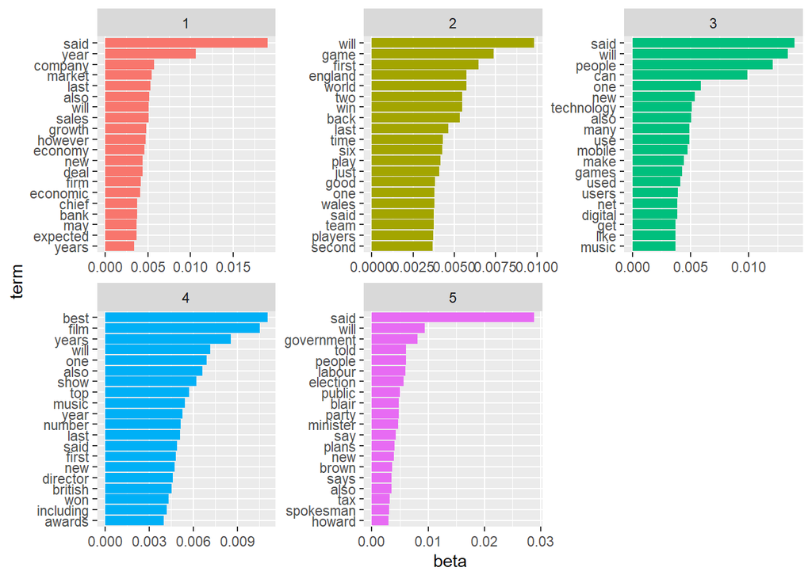

```r
lda_top_terms <- lda_topics %>%
  group_by(topic) %>%
  slice_max(beta, n = 20) %>% # We use dplyr’s slice_max() to find the top 10 terms within each topic.
  ungroup() %>%
  arrange(topic, -beta)

lda_top_terms %>%
  mutate(term = reorder_within(term, beta, topic)) %>%
  ggplot(aes(beta, term, fill = factor(topic))) +
  geom_col(show.legend = FALSE) +
  facet_wrap(~ topic, scales = "free") +
  scale_y_reordered()
```

**11: Use the code below to save the terms and topics in a wide format.**

```r
beta_wide <- lda_topics %>%
  mutate(topic = paste0("topic", topic)) %>%
  pivot_wider(names_from = topic, values_from = beta) %>%
  mutate(log_ratio21 = log2(topic2 / topic1)) %>%
  mutate(log_ratio31 = log2(topic3 / topic1))%>%
  mutate(log_ratio41 = log2(topic4 / topic1))%>%
  mutate(log_ratio51 = log2(topic5 / topic1))

beta_wide
```

```
## # A tibble: 30,856 x 10
##    term          topic1   topic2  topic3  topic4  topic5 log_ratio21 log_ratio31
##    <chr>          <dbl>    <dbl>   <dbl>   <dbl>   <dbl>       <dbl>       <dbl>
##  1 accounts     9.19e-4  1.06e-6 1.03e-4 1.26e-6 9.07e-7     -9.76       -3.16
##  2 adjust       5.32e-5  1.06e-6 9.24e-7 1.26e-6 9.07e-7     -5.65       -5.85
##  3 advert       1.04e-6  1.06e-6 6.56e-5 7.71e-5 9.07e-7      0.0220      5.98
##  4 advertising  1.78e-4  1.06e-6 2.87e-4 1.26e-6 9.07e-7     -7.40        0.689
##  5 alexander    1.04e-6  1.06e-6 1.02e-5 3.93e-4 9.07e-7      0.0220      3.29
##  6 already      6.89e-4  3.61e-4 1.97e-3 5.57e-4 1.04e-3     -0.933       1.51
##  7 also         5.13e-3  2.19e-3 5.06e-3 6.64e-3 3.49e-3     -1.23       -0.0214
##  8 amount       6.27e-4  1.06e-6 5.56e-4 1.26e-6 3.72e-5     -9.21       -0.174
##  9 analysts     2.81e-3  1.06e-6 1.30e-4 1.26e-6 9.07e-7    -11.4        -4.43
## 10 aol          1.04e-6  1.06e-6 2.60e-4 1.26e-6 9.07e-7      0.0220      7.96
## # ... with 30,846 more rows, and 2 more variables: log_ratio41 <dbl>,
## #   log_ratio51 <dbl>
```

**12: Use the log ratios to visualize the words with the greatest differences between topic 1 and other topics. Below you see this analysis for topics 1 and 2.**

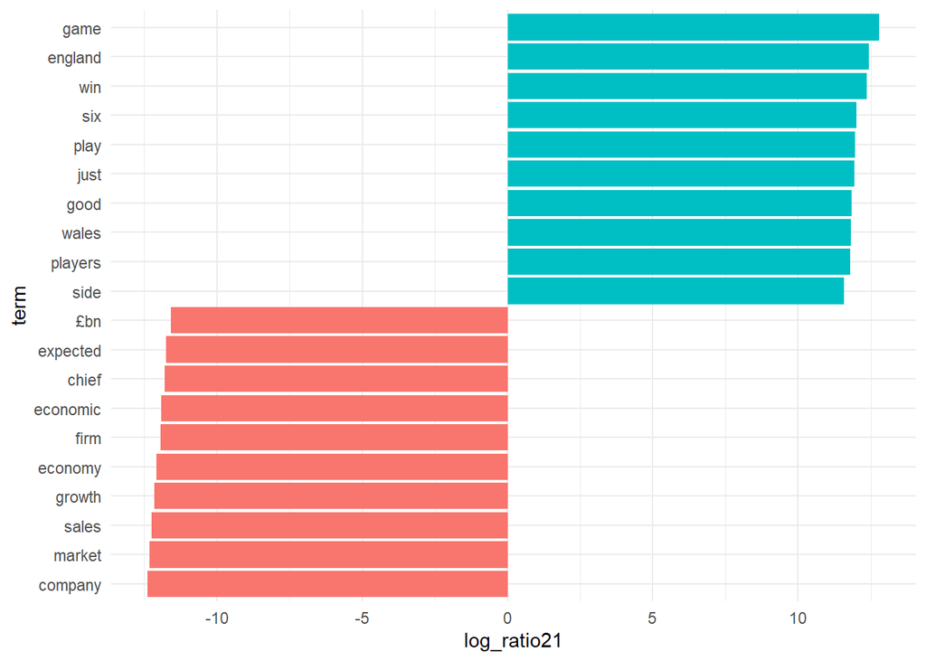

```r
# topic 1 versus topic 2
lda_top_terms1 <- beta_wide %>%
  slice_max(log_ratio21, n = 10) %>%
  arrange(term, -log_ratio21)

lda_top_terms2 <- beta_wide %>%
  slice_max(-log_ratio21, n = 10) %>%
  arrange(term, -log_ratio21)

lda_top_terms12 <- rbind(lda_top_terms1, lda_top_terms2)

# this is for ggplot to understand in which order to plot name on the x axis.
lda_top_terms12$term <- factor(lda_top_terms12$term, levels = lda_top_terms12$term[order(lda_top_terms12$log_ratio21)])

# Words with the greatest difference in beta between topic 2 and topic 1
lda_top_terms12 %>%
  ggplot(aes(log_ratio21, term, fill = (log_ratio21 > 0))) +
  geom_col(show.legend = FALSE) +
  scale_y_reordered() +
  theme_minimal()
```

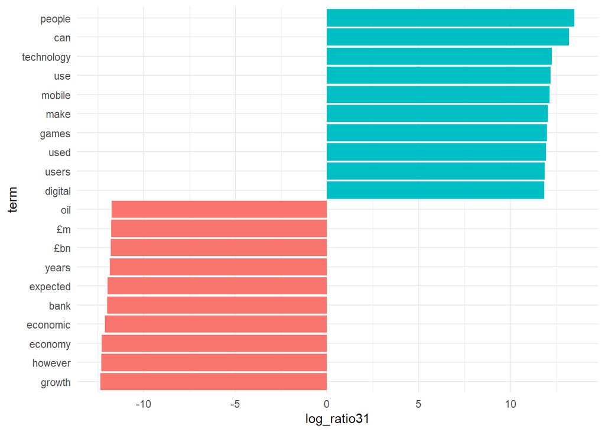

```r
# topic 1 versus topic 3
lda_top_terms1 <- beta_wide %>%
  slice_max(log_ratio31, n = 10) %>%
  arrange(term, -log_ratio31)

lda_top_terms2 <- beta_wide %>%
  slice_max(-log_ratio31, n = 10) %>%
  arrange(term, -log_ratio31)

lda_top_terms13 <- rbind(lda_top_terms1, lda_top_terms2)

# this is for ggplot to understand in which order to plot name on the x axis.
lda_top_terms13$term <- factor(lda_top_terms13$term, levels = lda_top_terms13$term[order(lda_top_terms13$log_ratio31)])

# Words with the greatest difference in beta between topic 2 and topic 1
lda_top_terms13 %>%
  ggplot(aes(log_ratio31, term, fill = (log_ratio31 > 0))) +
  geom_col(show.legend = FALSE) +
  scale_y_reordered() +
  theme_minimal()
```

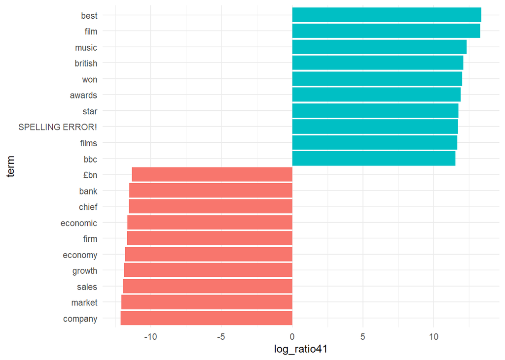

```r
# topic 1 versus topic 4
lda_top_terms1 <- beta_wide %>%
  slice_max(log_ratio41, n = 10) %>%
  arrange(term, -log_ratio41)

lda_top_terms2 <- beta_wide %>%
  slice_max(-log_ratio41, n = 10) %>%
  arrange(term, -log_ratio41)

lda_top_terms14 <- rbind(lda_top_terms1, lda_top_terms2)

lda_top_terms14[1,]$term <- 'SPELLING ERROR!'

# this is for ggplot to understand in which order to plot name on the x axis.
lda_top_terms14$term <- factor(lda_top_terms14$term, levels = lda_top_terms14$term[order(lda_top_terms14$log_ratio41)])

# Words with the greatest difference in beta between topic 2 and topic 1
lda_top_terms14 %>%
  ggplot(aes(log_ratio41, term, fill = (log_ratio41 > 0))) +
  geom_col(show.legend = FALSE) +
  scale_y_reordered() +
  theme_minimal()
```

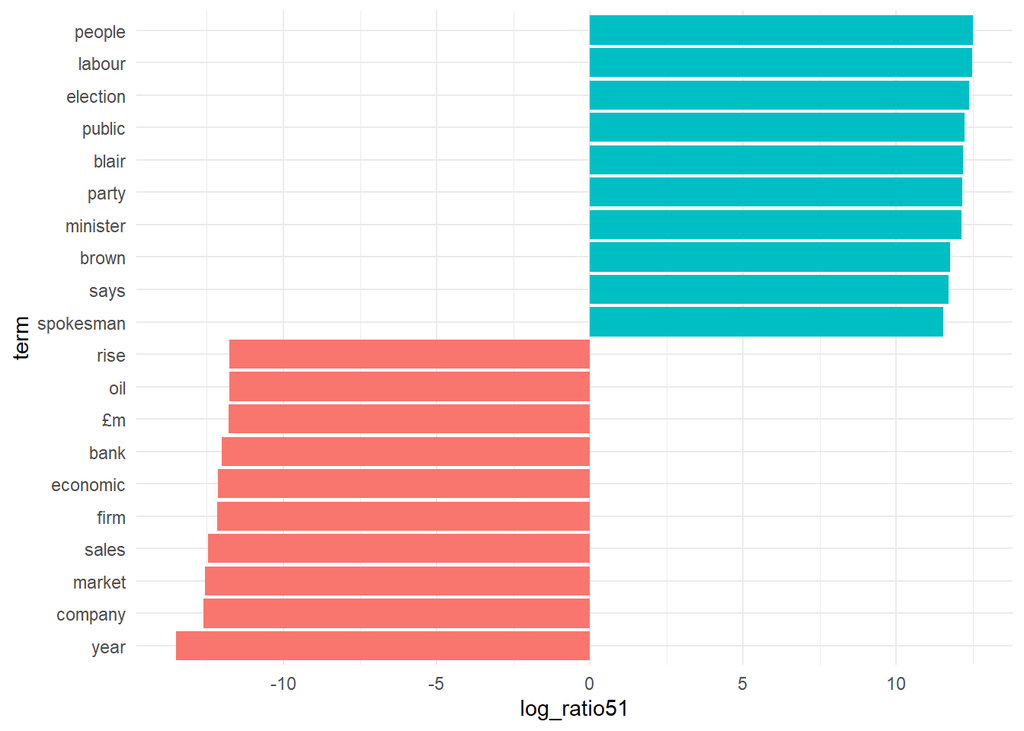

```r
# topic 1 versus topic 5
lda_top_terms1 <- beta_wide %>%
  slice_max(log_ratio51, n = 10) %>%
  arrange(term, -log_ratio51)

lda_top_terms2 <- beta_wide %>%
  slice_max(-log_ratio51, n = 10) %>%
  arrange(term, -log_ratio51)

lda_top_terms15 <- rbind(lda_top_terms1, lda_top_terms2)

# this is for ggplot to understand in which order to plot name on the x axis.
lda_top_terms15$term <- factor(lda_top_terms15$term, levels = lda_top_terms15$term[order(lda_top_terms15$log_ratio51)])

# Words with the greatest difference in beta between topic 2 and topic 1
lda_top_terms15 %>%
  ggplot(aes(log_ratio51, term, fill = (log_ratio51 > 0))) +
  geom_col(show.legend = FALSE) +
  scale_y_reordered() +
  theme_minimal()
```

**13: Besides estimating each topic as a mixture of words, LDA also models each document as a mixture of topics. We can examine the per-document-per-topic probabilities, called “gamma”, with the `matrix = "gamma"` argument in the `tidy()` function. Call this function for your LDA model and save the probabilities in a variable named `lda_documents`.**

```r
lda_documents <- tidy(out_lda, matrix = "gamma")
```

**14: Check the topic probabilities for documents with the index number of 1, 1000, 2000, 2225.**

```r
lda_documents[lda_documents$document == 1,]
```

```
## # A tibble: 5 x 3
##   document topic  gamma
##   <chr>    <int>  <dbl>
## 1 1            1 0.556
## 2 1            2 0.0490
## 3 1            3 0.203
## 4 1            4 0.133
## 5 1            5 0.0594
```

```r
lda_documents[lda_documents$document == 1000,]
```

```
## # A tibble: 5 x 3
##   document topic  gamma
##   <chr>    <int>  <dbl>
## 1 1000         1 0.0658
## 2 1000         2 0.107
## 3 1000         3 0.0784
## 4 1000         4 0.376
## 5 1000         5 0.373
```

```r
lda_documents[lda_documents$document == 2000,]
```

```
## # A tibble: 5 x 3
##   document topic  gamma
##   <chr>    <int>  <dbl>
## 1 2000         1 0.161
## 2 2000         2 0.0968
## 3 2000         3 0.286
## 4 2000         4 0.198
## 5 2000         5 0.258
```

```r
lda_documents[lda_documents$document == 2225,]
```

```
## # A tibble: 5 x 3
##   document topic  gamma
##   <chr>    <int>  <dbl>
## 1 2225         1 0.0300
## 2 2225         2 0.186
## 3 2225         3 0.522
## 4 2225         4 0.164
## 5 2225         5 0.0985
```

```r
tidy(dtm) %>%
  filter(document == 2225) %>%
  arrange(desc(count))
```

```
## # A tibble: 766 x 3
##    document term    count
##    <chr>    <chr>   <dbl>
##  1 2225     gaming     23
##  2 2225     game       22
##  3 2225     games      22
##  4 2225     online     22
##  5 2225     playing    20
##  6 2225     time       20
##  7 2225     hours      19
##  8 2225     can        15
##  9 2225     people     15
## 10 2225     play       15
## # ... with 756 more rows
```

**15: Use the code below to visualize the topic probabilities for the example documents in question 14.**

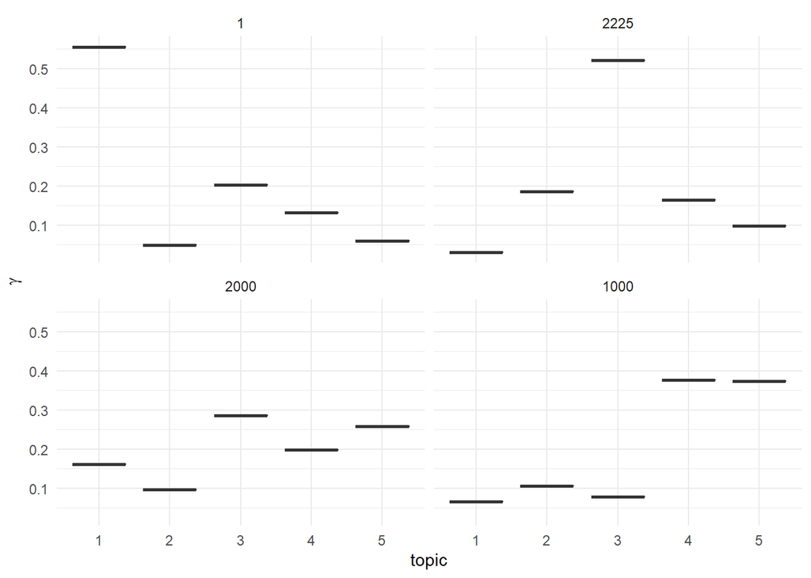

```r
# reorder titles in order of topic 1, topic 2, etc before plotting
lda_documents[lda_documents$document %in% c(1, 1000, 2000, 2225),] %>%
  mutate(document = reorder(document, gamma * topic)) %>%
  ggplot(aes(factor(topic), gamma)) +
  geom_boxplot() +
  facet_wrap(~ document) +
  labs(x = "topic", y = expression(gamma)) +
  theme_minimal()
```

# Alternative LDA implementations

The `LDA()` function in the `topicmodels` package is only one implementation of the latent Dirichlet allocation algorithm. For example, the `mallet` package (Mimno 2013) implements a wrapper around the MALLET Java package for text classification tools, and the `tidytext` package provides tidiers for this model output as well. The `textmineR` package has extensive functionality for topic modeling. You can fit Latent Dirichlet Allocation (LDA), Correlated Topic Models (CTM), and Latent Semantic Analysis (LSA) from within `textmineR`.